# Presentación Displex

En este documento se presenta una librería de herramientas en R para el cálculo de la disponibilidad léxica, para la que se pretende que sea una guía rápida de uso básico. Aunque la librería permite, a través de programación funcional, implementar múltiples modelos, se proporcionan un conjunto de herramientas básicas prediseñadas para que se pueda empezar a usar de forma casi inmediata. Sin embargo, consideramos necesario hacer notar que estas funciones de aplicación directa representan a un subconjunto de las posibilidades que permite el sistema y que se han utilizado como herramienta rápida más que como solución definitiva.

Hay otro trabajo en preparación en el que se discuten en profundidad los modelos y diferentes opciones, así como un estudio en profundidad de diferentes aspectos del cálculo de la disponibilidad y su interpretación. Sin embargo, el desarrollo de estas herramientas posteriores requeriría cierta soltura en el manejo de la sintaxis de R, así como con los conceptos de programación funcional.

# Exposición y contextualización del sistema

El sistema se ha implementado en R[^1], una implentación abierta del lenguaje de programación S, que lleva en desarrollo desde 1992 y con una primera versión estable en el año 2000. Es fácilmente extensible y permite la reutilización de código y datos, estando soportado por una amplia comunidad a lo largo del mundo y se usa de forma habitual en entornos de análisis de datos de ingeniería y medicina. RStudio[^2] es un entorno comercial de desarrollo para R que permite el uso personal gratuito y que aumenta la productividad en el uso de este lenguaje.

En particular, nos resulta especialmente interesante la posibilidad de usar el paradigma de la programación literaria, en la que, en el mismo documento, se van integrando los contenidos literarios como la exposición de hechos o la interpretación de los análisis, con bloques de código que llevan a cabo las manipulaciones y representaciones de datos. Este documento se ha creado siguiendo esta metodología, que potencia, además, la reutilización y replicabilidad, al integrar todo el proceso de producción científica en un mismo trabajo.

# Instalación

Se ha optado por el uso del repositorio GitHub.com. Esto implica que el usuario debe llevar a cabo un pequeño paso de instalación que, en nuestra opinión, no es más complejo que cualquier proceso de instalación en el sistema R. Este paso ha de hacerse únicamente cuando se pretenda instalar o actualizar el paquete en el sistema. Puesto que nuestra intención es seguir trabajando en el paquete, sería recomendable realizar esta acción de forma periódica.

Las siguientes órdenes instalan el paquete Displex del repositorio GitHub. Todo el código está implementado en R, con lo que es fácil de revisar.

```
install.packages("devtools")
library(devtools)
install_github("jmss70/displex")
```

Se recomienda el uso del universo TidyVerse para el análisis de datos, ya que proporciona herramientas con una sintaxis muy potente que facilita enormemente la tarea de análisis y representación de datos.

```
 install.packages("tidyverse")
 install.packages("kableExtra")
```

Llevados a cabo los pasos anteriores, y si no se ha producido ningún contratiempo, el sistema está preparado para llevar a cabo el trabajo.

# Carga de las librerías y los datos

Para poder usar las librerías hay que cargarlas en nuestra sesión de trabajo, poniendo a nuestra disposición las funciones que proporcionan:

```r
library(tidyverse)
library(kableExtra)
library(displex)
```

Para cargar los datos, se espera que estén en un determinado formato, utilizado por ser el que habitualmente se encuentra en este tipo de estudios, creemos que por razones históricas. Sin embargo, consideramos que son redundantes y que habría que estudiar, en un futuro cercano, establecer un estandard de codificación que sea más coherente con los modelos de datos normalizados.

Se espera que los datos estén en un archivo de texto, con campos separados por espacios: - Un campo de información del hablante - Un campo de identificación de usuario - Un campo de identificación de centro de interés - Una lista de palabras separadas por comas y en orden de realización

Un ejemplo de dos líneas sería:

```
21131 001 01 mano, pie, brazo, cerebro, pulmón, nariz, extremidad, ojo, boca, diente, pelo, oreja, culo, vagina
12131 002 01 riñón, corazón, garganta, cabeza, pierna, pie, hígado, estómago, mano, brazo, antebrazo, abdomen, pecho, ojo, boca, oído, dedo, rodilla, costilla
```

Suponiendo que tenemos todos los datos cargados en un archivo, denominado `datos.txt`, que estará alojado en el mismo directorio que el script de procesamiento, se podrían cargar los datos como:

```r
data <- read.displex("datos.txt")
data %>%
  head() %>%
  kbl()  %>%
  kable_styling(full_width = F)
```

| infos | users | centers | words |
| --- | --- | --- | --- |
| 21131 | 001 | 01 | mano, pi…. |
| 12131 | 002 | 01 | riñón, c…. |
| 12213 | 003 | 01 | brazo, m…. |
| 22214 | 004 | 01 | brazo, o…. |
| 12214 | 005 | 01 | cabeza, …. |
| 22213 | 006 | 01 | pie, man…. |

# Cálculo de la disponibilidad

La función general del cálculo de la disponibilidad es `displex_availability`. Sin embargo, el uso de esta función requiere del uso de varios parámetros. Se han construidos dos funciones de utilidad que encapsulan su uso y ofrecen los dos modelos que consideramos, por el momento, más interesantes. Consideramos que es preferible exponer su uso mediante ejemplos.

## Modelo de López-Strassburger

Este modelo, que es el conocido y el último de una serie de iteraciones para la cuantificación de la disponibilidad, se puede usar como:

```r
disponibilidad <- build.lopezstrass.availability(data)
```

Se construye entonces un nuevo marco de datos cuyos campos son el centro de interés, la palabra y la disponibilidad calculada, junto con otros datos respecto a los que se ha expresado interés, como la posición y las frecuencias relativas y acumuladas dentro del centro de interés:

```r
head(disponibilidad) %>%
  kbl() %>%
  kable_styling(full_width = F)
```

| centers | words | order | availability | freq.abs | freq.rel | freq.abs.cum | freq.rel.cum |
| --- | --- | --- | --- | --- | --- | --- | --- |
| 01 | ojo | 1 | 0.6329875 | 58 | 0.0373952 | 58 | 0.0373952 |
| 01 | brazo | 2 | 0.5518081 | 50 | 0.0322373 | 108 | 0.0696325 |
| 01 | pierna | 3 | 0.5072154 | 49 | 0.0315925 | 157 | 0.1012250 |
| 01 | mano | 4 | 0.4894822 | 42 | 0.0270793 | 373 | 0.2404900 |
| 01 | cabeza | 5 | 0.4780536 | 37 | 0.0238556 | 410 | 0.2643456 |
| 01 | pie | 6 | 0.4501276 | 43 | 0.0277240 | 331 | 0.2134107 |

Al ser un marco de datos de R estándard, se pueden realizar sobre el todas las operaciones que permite el sistema, como seleccionar los términos del centro de interés “03”, ordenarlos en orden decreciente de disponibilidad y ver los 10 más disponibles

```r
disponibilidad %>%
  filter(centers=="03") %>%
  arrange(-availability) %>%
  head(10) %>%
  kbl() %>% kable_styling(full_width = F)
```

| centers | words | order | availability | freq.abs | freq.rel | freq.abs.cum | freq.rel.cum |
| --- | --- | --- | --- | --- | --- | --- | --- |
| 03 | cocina | 1 | 0.8415694 | 69 | 0.0669253 | 69 | 0.0669253 |
| 03 | (cuarto de) baño | 2 | 0.7466699 | 66 | 0.0640155 | 135 | 0.1309408 |
| 03 | salón | 3 | 0.7155625 | 58 | 0.0562561 | 255 | 0.2473327 |
| 03 | dormitorio | 4 | 0.6367281 | 55 | 0.0533463 | 310 | 0.3006790 |
| 03 | terraza | 5 | 0.6085068 | 62 | 0.0601358 | 197 | 0.1910766 |
| 03 | comedor | 6 | 0.4391517 | 39 | 0.0378274 | 349 | 0.3385063 |
| 03 | salita | 7 | 0.3376176 | 31 | 0.0300679 | 447 | 0.4335597 |
| 03 | lavadero | 8 | 0.3180560 | 33 | 0.0320078 | 416 | 0.4034918 |
| 03 | pasillo | 9 | 0.3109779 | 34 | 0.0329777 | 383 | 0.3714840 |
| 03 | (cuarto de) aseo | 10 | 0.2585570 | 24 | 0.0232784 | 500 | 0.4849661 |

O representar la curva de disponibilidad, esto es, la sucesión de valores de disponibilidad, una vez ordenados en valor decreciente de disponibilidad:

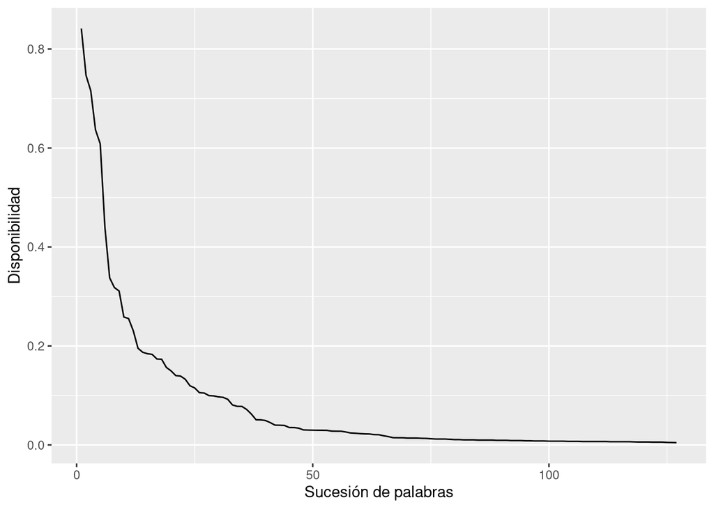

```r
disponibilidad %>%
  filter(centers=="03") %>%
  arrange(-availability) %>%
  ggplot(aes(x=order, y=availability)) + geom_line() +
  xlab("Sucesión de palabras") + ylab("Disponibilidad")
```

## Modelo de Ávila-Sánchez

Ávila y Sánchez proponen un macro-modelo para el estudio de la disponibilidad, a partir de la Teoría de los Conjuntos Difusos y mediante la modelización de los conceptos que se pretenden representar en estudios. Esta evaluación se produce en dos etapas. En la primera se cuantifica la relevancia de cada término en las pruebas obtenidas para cada hablante y centro de interés según una ley descendente según se avanza en cada listado, y en una segunda etapa se integra esa información con una ley aditiva que integra los distintos valores alcanzados para cada palabra en cada centro de interés.

Hay múltiples posibles elecciones, pero en distintas pruebas pareció más prometedoras las que utilizaban en la primera etapa una ley de Zipf-Mandelbrot y en la segunda una adición probabilística. La interpretación de los valores obtenidos corresponden a la “centralidad” de cada término en el centro de interés. Un valor de uno o muy cercano respondería a la pertenencia al núcleo del vocabulario específico del centro de interés, mientras que una valor próximo a cero indicaría que sería un término poco accesible.

```r
disponibilidad <- build.avilasanchez.availability(data)
```

Obteniéndose, de nuevo, un nuevo marco de datos con la disponibilidad de cada término en cada cnetro de interés

```r
disponibilidad %>%
  filter(centers=="03") %>%
  arrange(-availability) %>%
  head(10) %>%
  kable() %>%
  kable_styling(full_width = F)
```

| centers | words | order | availability | freq.abs | freq.rel | freq.abs.cum | freq.rel.cum |
| --- | --- | --- | --- | --- | --- | --- | --- |
| 03 | cocina | 1 | 1.0000000 | 69 | 0.0669253 | 69 | 0.0669253 |
| 03 | salón | 2 | 1.0000000 | 58 | 0.0562561 | 255 | 0.2473327 |
| 03 | (cuarto de) baño | 3 | 1.0000000 | 66 | 0.0640155 | 135 | 0.1309408 |
| 03 | dormitorio | 4 | 0.9999996 | 55 | 0.0533463 | 310 | 0.3006790 |
| 03 | comedor | 5 | 0.9999278 | 39 | 0.0378274 | 349 | 0.3385063 |
| 03 | terraza | 6 | 0.9999003 | 62 | 0.0601358 | 197 | 0.1910766 |
| 03 | salita | 7 | 0.9974380 | 31 | 0.0300679 | 447 | 0.4335597 |
| 03 | entrada | 8 | 0.9961966 | 23 | 0.0223084 | 523 | 0.5072745 |
| 03 | (cuarto de) aseo | 9 | 0.9947151 | 24 | 0.0232784 | 500 | 0.4849661 |
| 03 | pasillo | 10 | 0.9884745 | 34 | 0.0329777 | 383 | 0.3714840 |

Que se puede procesar como cualquier marco de datos del sistema R:

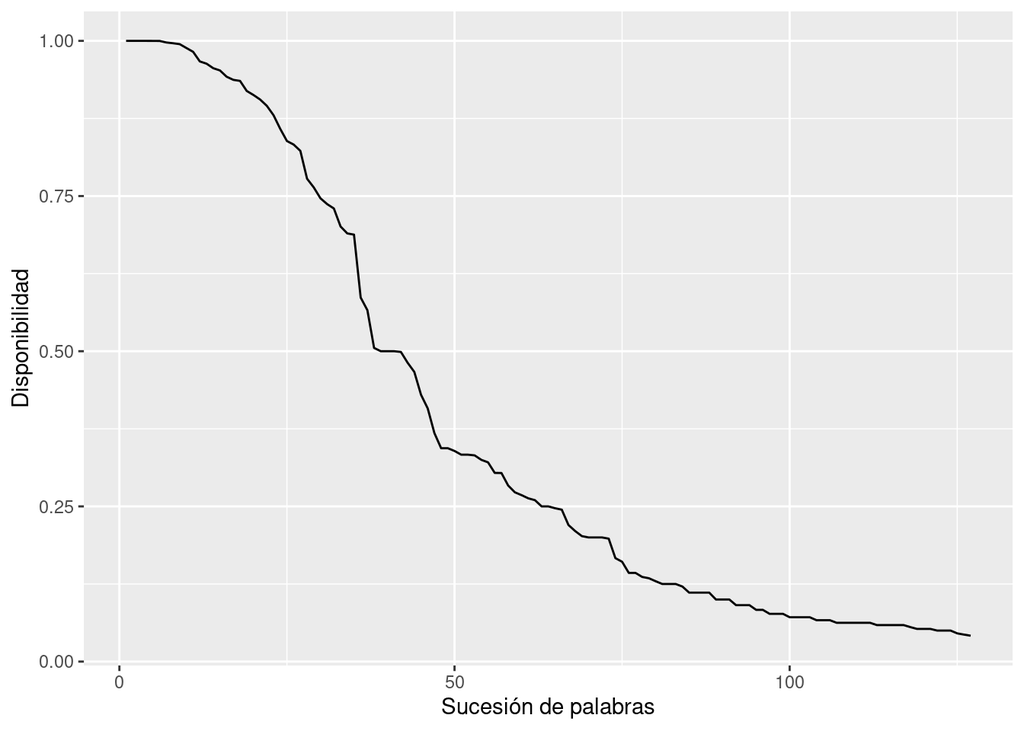

```r
disponibilidad %>%
  filter(centers=="03") %>%
  arrange(-availability) %>%
  ggplot(aes(x=order, y=availability)) + geom_line() +
  xlab("Sucesión de palabras") + ylab("Disponibilidad")
```

Debido a las características de los operadores aditivos de la teoría de los conjuntos difusos, es posible que la forma de la curva no sea la esperada, no habíendo términos con valoraciones cercanas a uno (por ejemplo, si se tienen pocos datos y relativamente dispersos) o demasiados términos con valoraciones cercanas a uno (por ejemplo, si se tienen muchas muestras). Considerando esta situación, se puede regular la curva mediante un parámetro adicional, $k$, que va a “subir” o “bajar” la curva, pero manteniendo su forma y clasificación. El valor por defecto de $k$ es uno. Si se da un valor entre $0$ y $1$, la curva “bajará” (menos términos con valores cercanos a uno), mientras que si a $k$ se le da un valor mayor que la unidad la curva “subirá” (más términos cercanos a la unidad).

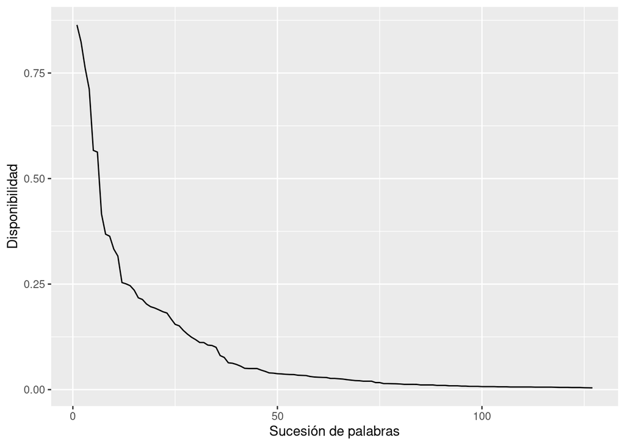

```r
disponibilidad <- build.avilasanchez.availability(data, k = 0.1)
disponibilidad %>%
  filter(centers=="03") %>%
  arrange(-availability) %>%
  ggplot(aes(x=order, y=availability)) + geom_line() +
  xlab("Sucesión de palabras") + ylab("Disponibilidad")
```

Obteniéndose, de nuevo, un nuevo marco de datos con la disponibilidad de cada término en cada cnetro de interés

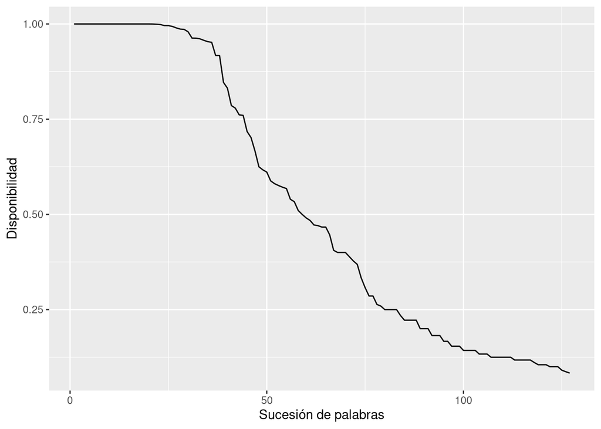

```r
disponibilidad <- build.avilasanchez.availability(data, k = 2)
disponibilidad %>%
  filter(centers=="03") %>%
  arrange(-availability) %>%
  ggplot(aes(x=seq_along(availability), y=availability)) + geom_line() +
  xlab("Sucesión de palabras") + ylab("Disponibilidad")
```

Téngase en cuenta que estos dos ejemplos son a modo de exposición y para valores muy extremos. En nuestras pruebas hemos encontrado que el valor de referencia es lo suficientemente bueno en todos los casos que hemos encontrado.

# Niveles de disponibilidad

Una pregunta recurrente es considerar cual es el tamaño del conjunto de elementos que se consideran que forman parte del núcleo de un centro de interés. Para responder a esta cuestión, y a partir del marco teórico que se ha utilizado en nuestra propuesta, se proporciona una herramienta que etiqueta los términos en niveles de centralidad. El nivel 0 corresponderían a aquellos elementos que no pertenecen al núcleo, es decir, aquellos términos que no son generalmente accesibles. Los níveles 1, 2, 3, … y sucesivos representarían un mayor grado de centralidad en el centro de interés.

```r
disponibilidad <- build.avilasanchez.availability(data)
```

```r
levels <- classify.availability.levels(disponibilidad)
levels %>%
  head(20) %>%
  arrange(-availability) %>%
  select(-order) %>%
  kbl() %>%
  kable_styling(full_width = F)
```

| centers | words | availability | level | cutlevel | freq.abs | freq.rel | freq.abs.cum | freq.rel.cum |
| --- | --- | --- | --- | --- | --- | --- | --- | --- |
| 14 | perro | 1 | 6 | 0.9497065 | 67 | 0.0420590 | 67 | 0.0420590 |
| 12 | coche | 1 | 6 | 0.9589061 | 65 | 0.0571680 | 65 | 0.0571680 |
| 19 | rojo | 1 | 6 | 0.9614247 | 66 | 0.0525478 | 203 | 0.1616242 |
| 03 | cocina | 1 | 6 | 0.9638074 | 69 | 0.0669253 | 69 | 0.0669253 |
| 19 | azul | 1 | 6 | 0.9614247 | 68 | 0.0541401 | 137 | 0.1090764 |
| 14 | gato | 1 | 6 | 0.9497065 | 64 | 0.0401758 | 131 | 0.0822348 |
| 04 | mesa | 1 | 6 | 0.9562246 | 54 | 0.0518234 | 230 | 0.2207294 |
| 03 | salón | 1 | 6 | 0.9638074 | 58 | 0.0562561 | 255 | 0.2473327 |
| 17 | euro | 1 | 6 | 0.9439173 | 45 | 0.0401427 | 45 | 0.0401427 |
| 09 | aire acondicionado | 1 | 6 | 0.9583219 | 58 | 0.0782726 | 118 | 0.1592443 |
| 06 | tenedor | 1 | 6 | 0.9551142 | 59 | 0.0552952 | 59 | 0.0552952 |
| 11 | árbol | 1 | 6 | 0.9384632 | 51 | 0.0404762 | 51 | 0.0404762 |
| 08 | pizarra | 1 | 6 | 0.9505229 | 62 | 0.0476923 | 62 | 0.0476923 |
| 10 | calle | 1 | 6 | 0.9527790 | 51 | 0.0378338 | 51 | 0.0378338 |
| 20 | ola | 1 | 6 | 0.9436923 | 46 | 0.0343028 | 97 | 0.0723341 |
| 04 | silla | 1 | 6 | 0.9562246 | 63 | 0.0604607 | 63 | 0.0604607 |
| 09 | ventilador | 1 | 6 | 0.9583219 | 60 | 0.0809717 | 60 | 0.0809717 |
| 02 | pantalón | 1 | 6 | 0.9576618 | 62 | 0.0482866 | 62 | 0.0482866 |
| 08 | mesa | 1 | 6 | 0.9505229 | 46 | 0.0353846 | 385 | 0.2961538 |
| 01 | cabeza | 1 | 6 | 0.9576033 | 37 | 0.0238556 | 410 | 0.2643456 |

```r
levels %>%
  filter(centers=="01") %>%
  arrange(-availability)   %>%
  #head(20) %>%
  filter(level > 0) %>%
  select(-order) %>%
  kable(longtable=TRUE,booktabs=TRUE) %>%
  kable_styling(latex_options = c("hold_position", "repeat_header")) # %>%
```

| centers | words | availability | level | cutlevel | freq.abs | freq.rel | freq.abs.cum | freq.rel.cum |
| --- | --- | --- | --- | --- | --- | --- | --- | --- |
| 01 | cabeza | 1.0000000 | 6 | 0.9576033 | 37 | 0.0238556 | 410 | 0.2643456 |
| 01 | brazo | 0.9999999 | 6 | 0.9576033 | 50 | 0.0322373 | 108 | 0.0696325 |
| 01 | ojo | 0.9999996 | 6 | 0.9576033 | 58 | 0.0373952 | 58 | 0.0373952 |
| 01 | mano | 0.9999963 | 6 | 0.9576033 | 42 | 0.0270793 | 373 | 0.2404900 |
| 01 | pierna | 0.9999664 | 6 | 0.9576033 | 49 | 0.0315925 | 157 | 0.1012250 |
| 01 | pie | 0.9999228 | 6 | 0.9576033 | 43 | 0.0277240 | 331 | 0.2134107 |
| 01 | corazón | 0.9993747 | 6 | 0.9576033 | 44 | 0.0283688 | 201 | 0.1295938 |
| 01 | dedo | 0.9981017 | 6 | 0.9576033 | 44 | 0.0283688 | 245 | 0.1579626 |
| 01 | nariz | 0.9978564 | 6 | 0.9576033 | 43 | 0.0277240 | 288 | 0.1856867 |
| 01 | boca | 0.9948986 | 6 | 0.9576033 | 33 | 0.0212766 | 479 | 0.3088330 |
| 01 | pelo | 0.9923933 | 6 | 0.9576033 | 27 | 0.0174081 | 595 | 0.3836235 |
| 01 | oreja | 0.9863368 | 6 | 0.9576033 | 29 | 0.0186976 | 568 | 0.3662153 |
| 01 | hueso | 0.9759572 | 6 | 0.9576033 | 21 | 0.0135397 | 686 | 0.4422953 |
| 01 | hígado | 0.9701666 | 6 | 0.9576033 | 29 | 0.0186976 | 539 | 0.3475177 |
| 01 | músculo | 0.9674082 | 6 | 0.9576033 | 19 | 0.0122502 | 705 | 0.4545455 |
| 01 | tronco | 0.9664685 | 6 | 0.9576033 | 10 | 0.0064475 | 1040 | 0.6705351 |
| 01 | uña | 0.9645619 | 6 | 0.9576033 | 36 | 0.0232108 | 446 | 0.2875564 |
| 01 | pulmón | 0.9271497 | 5 | 0.9197114 | 31 | 0.0199871 | 510 | 0.3288201 |
| 01 | riñón | 0.9197114 | 5 | 0.9197114 | 23 | 0.0148291 | 643 | 0.4145712 |
| 01 | estómago | 0.9119534 | 4 | 0.8569412 | 25 | 0.0161186 | 620 | 0.3997421 |
| 01 | extremidad | 0.8827436 | 4 | 0.8569412 | 8 | 0.0051580 | 1084 | 0.6989039 |
| 01 | ceja | 0.8670245 | 4 | 0.8569412 | 18 | 0.0116054 | 723 | 0.4661509 |
| 01 | oído | 0.8591329 | 4 | 0.8569412 | 13 | 0.0083817 | 851 | 0.5486783 |
| 01 | órgano | 0.8569412 | 4 | 0.8569412 | 7 | 0.0045132 | 1134 | 0.7311412 |
| 01 | cara | 0.8460897 | 3 | 0.7652840 | 10 | 0.0064475 | 1000 | 0.6447453 |
| 01 | cerebro | 0.8439199 | 3 | 0.7652840 | 12 | 0.0077369 | 876 | 0.5647969 |
| 01 | codo | 0.8122445 | 3 | 0.7652840 | 18 | 0.0116054 | 741 | 0.4777563 |
| 01 | páncreas | 0.7808868 | 3 | 0.7652840 | 18 | 0.0116054 | 777 | 0.5009671 |
| 01 | rodilla | 0.7777151 | 3 | 0.7652840 | 22 | 0.0141844 | 665 | 0.4287556 |
| 01 | diente | 0.7732121 | 3 | 0.7652840 | 18 | 0.0116054 | 759 | 0.4893617 |
| 01 | sangre | 0.7671473 | 3 | 0.7652840 | 16 | 0.0103159 | 809 | 0.5215990 |
| 01 | hombro | 0.7665272 | 3 | 0.7652840 | 14 | 0.0090264 | 838 | 0.5402966 |
| 01 | cuello | 0.7364473 | 2 | 0.6196081 | 16 | 0.0103159 | 793 | 0.5112830 |
| 01 | esqueleto | 0.7037037 | 2 | 0.6196081 | 4 | 0.0025790 | 1216 | 0.7840103 |
| 01 | pestaña | 0.6988165 | 2 | 0.6196081 | 13 | 0.0083817 | 864 | 0.5570600 |
| 01 | cintura | 0.6980489 | 2 | 0.6196081 | 9 | 0.0058027 | 1058 | 0.6821406 |
| 01 | tibia | 0.6939048 | 2 | 0.6196081 | 10 | 0.0064475 | 1030 | 0.6640877 |
| 01 | antebrazo | 0.6892100 | 2 | 0.6196081 | 11 | 0.0070922 | 935 | 0.6028369 |
| 01 | lengua | 0.6713687 | 2 | 0.6196081 | 12 | 0.0077369 | 912 | 0.5880077 |
| 01 | tobillo | 0.6612064 | 2 | 0.6196081 | 15 | 0.0096712 | 824 | 0.5312701 |
| 01 | vello | 0.6196081 | 2 | 0.6196081 | 6 | 0.0038685 | 1176 | 0.7582205 |
| 01 | vena | 0.6134745 | 1 | 0.4626262 | 11 | 0.0070922 | 990 | 0.6382979 |
| 01 | enfermedad | 0.6022542 | 1 | 0.4626262 | 5 | 0.0032237 | 1186 | 0.7646680 |
| 01 | espalda | 0.5956868 | 1 | 0.4626262 | 12 | 0.0077369 | 888 | 0.5725338 |
| 01 | pecho | 0.5909764 | 1 | 0.4626262 | 12 | 0.0077369 | 924 | 0.5957447 |
| 01 | labio | 0.5902379 | 1 | 0.4626262 | 10 | 0.0064475 | 1020 | 0.6576402 |
| 01 | garganta | 0.5690848 | 1 | 0.4626262 | 7 | 0.0045132 | 1120 | 0.7221148 |
| 01 | peroné | 0.5634803 | 1 | 0.4626262 | 9 | 0.0058027 | 1076 | 0.6937460 |
| 01 | muñeca | 0.5631837 | 1 | 0.4626262 | 11 | 0.0070922 | 968 | 0.6241135 |
| 01 | bazo | 0.5447121 | 1 | 0.4626262 | 11 | 0.0070922 | 946 | 0.6099291 |
| 01 | esófago | 0.5446623 | 1 | 0.4626262 | 11 | 0.0070922 | 957 | 0.6170213 |
| 01 | culo | 0.5344353 | 1 | 0.4626262 | 7 | 0.0045132 | 1113 | 0.7176015 |
| 01 | fémur | 0.5278453 | 1 | 0.4626262 | 12 | 0.0077369 | 900 | 0.5802708 |
| 01 | torso | 0.5112414 | 1 | 0.4626262 | 4 | 0.0025790 | 1260 | 0.8123791 |
| 01 | salud | 0.5040258 | 1 | 0.4626262 | 4 | 0.0025790 | 1248 | 0.8046422 |
| 01 | barriga | 0.5026316 | 1 | 0.4626262 | 4 | 0.0025790 | 1208 | 0.7788524 |
| 01 | cadera | 0.4839148 | 1 | 0.4626262 | 9 | 0.0058027 | 1049 | 0.6763378 |
| 01 | falange | 0.4690370 | 1 | 0.4626262 | 10 | 0.0064475 | 1010 | 0.6511928 |
| 01 | piel | 0.4626262 | 1 | 0.4626262 | 11 | 0.0070922 | 979 | 0.6312057 |

```r
  #column_spec(2, width = "10em")
```

Se puede construir con esta información una representación en la que se observan la distribución de las disponibilidades en el centro de interés y los diferentes conjuntos de cortes.

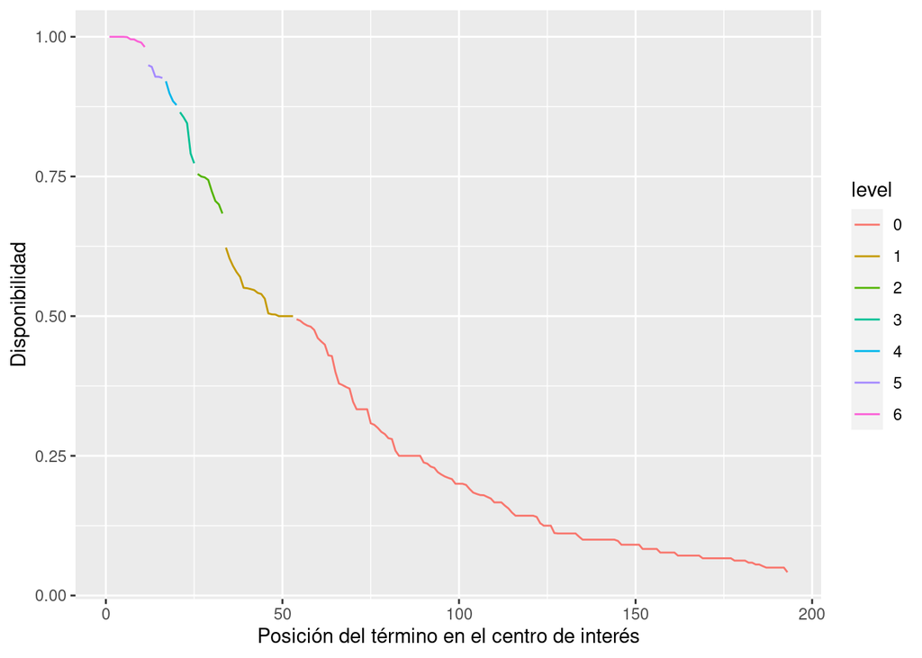

```r
levels %>%
  filter(centers=="04") %>%
  mutate(level=factor(level)) %>%
  arrange(-availability) %>%
  ggplot(aes(x=order,y=availability,color=level)) + geom_line() +
  xlab("Posición del término en el centro de interés") +
  ylab("Disponibilidad")
```

```r
clasificacion <- build.availability.levels(levels)
```

```r
clasificacion %>% filter(levels> 0)  %>%
  kable(longtable=TRUE,booktabs=TRUE) %>%
  kable_styling(latex_options = c("hold_position", "repeat_header")) %>%
  column_spec(4, width = "35em")
```

| centers | levels | count | words |
| --- | --- | --- | --- |
| 01 | 6 | 17 | cabeza , brazo , ojo , mano , pierna , pie , corazón, dedo , nariz , boca , pelo , oreja , hueso , hígado , músculo, tronco , uña |
| 01 | 5 | 2 | pulmón, riñón |
| 01 | 4 | 5 | estómago , extremidad, ceja , oído , órgano |
| 01 | 3 | 8 | cara , cerebro , codo , páncreas, rodilla , diente , sangre , hombro |
| 01 | 2 | 9 | cuello , esqueleto, pestaña , cintura , tibia , antebrazo, lengua , tobillo , vello |
| 01 | 1 | 18 | vena , enfermedad, espalda , pecho , labio , garganta , peroné , muñeca , bazo , esófago , culo , fémur , torso , salud , barriga , cadera , falange , piel |
| 02 | 6 | 16 | pantalón , camisa , falda , camiseta , calcetín , jersey , vestido , zapato , abrigo , chaqueta , blusa , braga , calzoncillo, sujetador , bufanda , corbata |
| 02 | 5 | 1 | (pantalón) vaquero |
| 02 | 4 | 5 | moda , tejido , media , sombrero, bañador |
| 02 | 3 | 7 | zapatilla, chándal , traje , camisón , anorak , bermudas , tanga |
| 02 | 2 | 10 | cinturón , biquini , rebeca , gorro , color , pijama , bolso , guante , necesario, chaleco |
| 02 | 1 | 18 | estilo , vestir , chaquetón , pañuelo , felpa , rebajas , diseño , comodidad , gabardina , botón , lana , (pantalón) pirata, falda vaquera , vestimenta , bota , sudadera , slip , algodón |
| 03 | 6 | 12 | cocina , salón , (cuarto de) baño, dormitorio , comedor , terraza , salita , entrada , (cuarto de) aseo, pasillo , lavadero , ventana |
| 03 | 5 | 4 | hall , recibidor , (cuarto) trastero, habitación |
| 03 | 4 | 6 | tejado , jardín , techo , escalera , sala de estar, vestidor |
| 03 | 3 | 5 | patio , garaje, pared , porche, balcón |
| 03 | 2 | 5 | despensa , buhardilla, sótano , suelo , vestíbulo |
| 03 | 1 | 5 | chimenea, puerta , despacho, azotea , estudio |
| 04 | 6 | 11 | mesa , silla , cama , sofá , sillón , armario , mesita de noche, aparador , cómoda , estantería , lámpara |
| 04 | 5 | 5 | ropero , mesa de comedor, espejo , vitrina , encimera |
| 04 | 4 | 4 | cuadro , lavadora , librería , frigorífico |
| 04 | 3 | 5 | tresillo , mueble de cocina, mueble-bar , lavavajillas , zapatero |
| 04 | 2 | 8 | butaca , tele(visión) , mesilla de noche, escritorio , repisa , taquillón , tocador , cajonera |
| 04 | 1 | 20 | sinfonier , hornilla , lámpara de techo , mueble de salón , alacena , mesa camilla , cama de matrimonio , mesa de tele(visión), taburete , comodín , mecedora , televisor , mesa de salón , ordenador , … |
| 05 | 6 | 21 | pan , carne , leche , tomate , huevo , lenteja , arroz , patata , garbanzo , verdura , pescado , fruta , manzana , cebolla , lechuga , agua , plátano , pera , pimiento , mantequilla, naranja |
| 05 | 5 | 2 | aceite, pasta |
| 05 | 4 | 7 | queso , jamón , melón , sandía, azúcar, pollo , judía |
| 05 | 3 | 7 | yogur , melocotón , chocolate , legumbre , fresa , carne de cerdo, alcachofa |
| 05 | 2 | 15 | zanahoria , carne de ternera, ensalada , maíz , café , uva , coliflor , calabacín , harina , chorizo , espinaca , hamburguesa , espagueti , sopa , bocadillo |
| 05 | 1 | 24 | kiwi , refresco , salchichón , cerdo , macarrón , berenjena , galleta , carne de pollo, vino , zumo , dulce , gazpacho , hortaliza , sal , cereal , fideo , filete , limón , mandarina , pepino , col , … |

[output cut: 90 more lines]

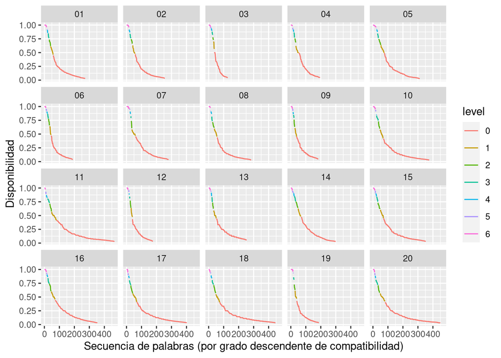

```r
levels %>%
  mutate(level=factor(level)) %>%
  arrange(-availability) %>%
  ggplot(aes(x=order,y=availability,color=level)) + geom_line() + facet_wrap(~centers)  +
  xlab("Secuencia de palabras (por grado descendente de compatibilidad)") +
  ylab("Disponibilidad")
```

[^1]: https://www.r-project.org/
[^2]: https://rstudio.com/